# Flexible Damage Functions

Author

James Rising, Sebastian Cadavid Sanchez, Climate Impact Lab

Published

April 30, 2026

## 0.1 Agriculture: Sorghum Country

Flexible damage function parameters at the Country level.

**Change in sorghum yields (log change in yields) under full adaptation**

**Outcome units:** `physical` — log change in sorghum yield (population-weighted to country)

$$D_{it} = (\alpha_i T_t + \beta_i T_t^2) \cdot Y_{it}^{\gamma}$$

where $\gamma$ is the income elasticity (fitted globally), $\alpha_i$ is the linear coefficient, and $\beta_i$ is the quadratic coefficient.

# 1 Global Estimation

## 1.1 Income Elasticity Estimation

The income elasticity $\gamma$ is estimated using a fixed-effects regression:

$$y_{it} = \gamma \cdot \log(Y_{it}) + \mu_{g(i,T)} + \nu_t + \varepsilon_{it}$$

where $\mu_{g(i,T)}$ are region-by-temperature-bin fixed effects and $\nu_t$ are year fixed effects.

Table 1: Income Elasticity (Gamma) Estimation Results

| Statistic | Value |
| --- | --- |
| Income elasticity ($\gamma$) | 0.0080 |
| Standard error | 1.55e-03 |
| 95% CI | [0.0049, 0.0110] |
| R-squared | 0.6710 |
| Observations | 2,932,701 |
| Regions | 141 |
| Gamma quantiles | 19 |

# 2 Parameter Distributions

## 2.1 8-Panel Summary

Row 1: gamma, alpha, beta, rsqr1. Row 2: rho, zeta, eta, rsqr2.

```
Using median gamma: 0.007975, 141 rows (of 2,679 total)
```

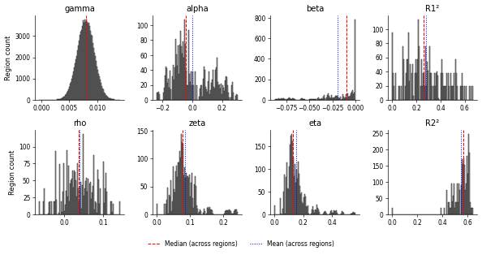

Figure 1: Distribution of Regional Parameters

## 2.2 Projection Equation and Parameter Definitions

The estimated parameters are used to project damages via Monte Carlo sampling:

$$D_{it}^k = (\hat{\alpha}_{ik} T_t + \hat{\beta}_{ik} T_t^2) Y_{it}^{\hat{\gamma}_k} + \hat{\theta}_{ik} T_t Y_{it}^{\hat{\gamma}_k} + \hat{\phi}_{it}^k$$

where $k$ indexes the Monte Carlo draw. The parameters in each row of the output CSV control distinct components of this equation:

- **gamma**: income elasticity $\hat{\gamma}_k$, one of 19 quantile values drawn from $N(\hat{\gamma}, SE(\hat{\gamma}))$
- **alpha, beta**: linear and quadratic temperature coefficients; $\hat{\alpha}_{ik}$ and $\hat{\beta}_{ik}$ are drawn from the joint normal defined by the VCV below
- **sigma11, sigma12, sigma22**: variance-covariance matrix of $(\alpha, \beta)$, used for joint uncertainty sampling
- **rho**: correlation between regional and global polynomial residuals $\rho_i$, used to maintain spatial covariance across regions in Monte Carlo draws
- **zeta**: temperature-dependent error scale $\zeta_{ik}$; the run-specific error term $\hat{\theta}_{ik}$ is drawn from $N(0, \zeta_{ik})$
- **eta**: residual noise standard deviation $\eta_{ik}$; the annual noise $\hat{\phi}_{it}^k$ is drawn from $N(0, \eta_{ik})$
- **rsqr1, rsqr2**: polynomial fit quality and error model fit, respectively

## 2.3 Summary Statistics

Table 2: Regional Parameter Summary

| Parameter | Mean | Median | Std | Min | Max | N |
| --- | --- | --- | --- | --- | --- | --- |
| alpha | -0.001735 | -0.04532 | 0.1286 | -0.2343 | 0.2967 | 141 |
| beta | -0.01965 | -0.009827 | 0.02386 | -0.08577 | 0 | 141 |
| rho | 0.0396 | 0.03719 | 0.04319 | -0.06526 | 0.1441 | 140 |
| zeta | 0.08415 | 0.07728 | 0.03838 | 0 | 0.2384 | 141 |
| eta | 0.1509 | 0.1307 | 0.07985 | 0 | 0.5465 | 141 |
| rsqr1 | 0.2832 | 0.2628 | 0.1674 | 0 | 0.6685 | 141 |
| rsqr2 | 0.5517 | 0.568 | 0.0718 | 0 | 0.6457 | 141 |

# 3 Spaghetti Curves

Regional damage function curves showing D(T) = αT + βT² for sampled regions.

[interactive chart not shown]

Figure 2: Regional Damage Functions

# 4 Zero Crossings

The zero crossing (extremum) of the parabola occurs at $T^* = -\alpha / (2\beta)$.

Table 3: Zero Crossing Statistics

| Category | Count | Percentage |
| --- | --- | --- |
| β = 0 (no crossing) | 39 | 27.7% |
| T > 20°C (beyond graph) | 1 | 0.7% |
| T < 0°C (negative crossing) | 55 | 39.0% |
| Valid crossings (0-20°C) | 46 | 32.6% |

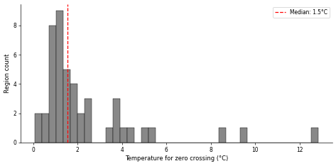

Figure 3: Distribution of Zero Crossing Temperatures

# 5 Slope Analysis

Maximum slope between 0 and 10°C: $\frac{dM}{dT} = \alpha + 2\beta T$

The maximum occurs at either T=0 or T=10 (endpoints of interval).

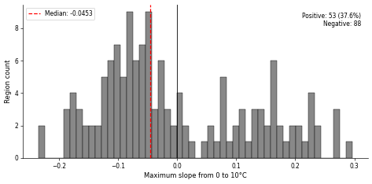

Figure 4: Distribution of Maximum Slopes (0-10°C)

*Convexity analysis omitted (beta constraint active).*

# 6 R-squared Analysis

## 6.1 Polynomial Fit Quality (rsqr1)

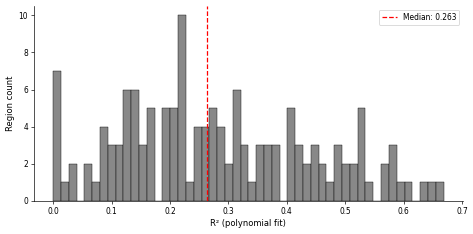

Figure 5: Regional Fit Quality (R-squared)

## 6.2 Error Model R-squared (rsqr2) Quantiles

Table 4: rsqr2 Quantiles

| 0% (Min) | 25% | 50% (Median) | 75% | 100% (Max) |
| --- | --- | --- | --- | --- |
| 0.0000 | 0.5204 | 0.5680 | 0.6001 | 0.6457 |

# 7 Modelled Variance

Modelled variance statistic: $1 - \frac{\sum_i \eta_i^2}{\sum_i D_i^2}$

Table 5: Modelled Variance Statistics

| Statistic | Value |
| --- | --- |
| Modelled variance | 0.7576 |
| Sum(η²) | 4.1021 |
| Sum(D²) at T=3.0°C | 16.9226 |
| N regions | 141 |

# 8 Best- and Worst-Fitting Regions

The 3 worst- and 3 best-fitting regions by R-squared, with raw simulation data overlaid on the fitted polynomial curve. **Red rows = worst fits**, **green rows = best fits**.

Table 6: Best- and worst-fitting regions

Top 3 best fit (R²) Top 3 worst fit (R²)

| Region | α | β | η | R² |
| --- | --- | --- | --- | --- |
| BRA | -0.0736 | -0.0234 | 0.0823 | 0.668 |
| ISR | -5.20e-4 | -0.0437 | 0.0933 | 0.653 |
| GRC | 0.108 | -0.0725 | 0.111 | 0.64 |
| YEM | 0.0169 | -0.00164 | 0.12 | 0.00318 |
| NPL | 0.155 | -0.0337 | 0.472 | 0.00493 |
| LSO | 0.062 | -0.0164 | 0.203 | 0.00653 |

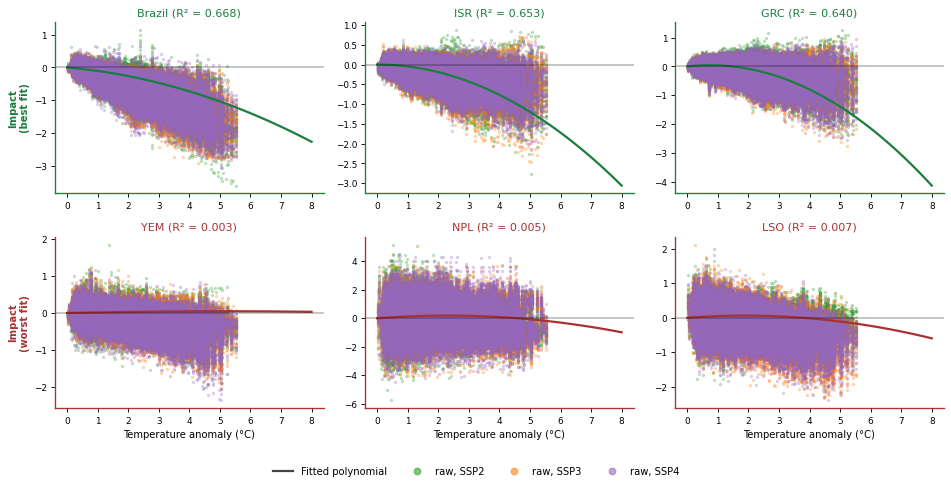

# 9 Regional Parameter Maps

Maps of key parameters at the **country** level. Red = negative (damage increases with T), Blue = positive.

## 9.1 Alpha (Linear Coefficient)

Alpha ($\alpha$) represents the linear sensitivity to temperature. Regions with negative alpha experience damage that increases with the first degree of warming.

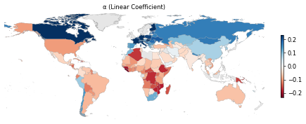

Figure 7: α (linear coefficient)

## 9.2 Beta (Quadratic Coefficient)

Beta ($\beta$) represents the curvature of the damage function.

The concavity ($\beta \leq 0$) constraint is enforced for this sector, meaning optimal temperature exists, damages accelerate beyond it.

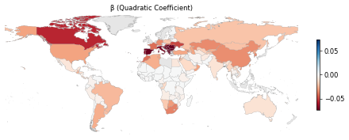

Figure 8: β (quadratic coefficient)

## 9.3 R-squared (Fit Quality)

$R^2$ measures the polynomial fit quality. Higher values indicate that the quadratic form captures more of the variance in the data.

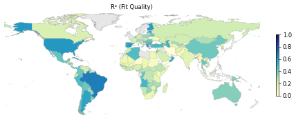

Figure 9: R² (stage 1 fit quality)

# 10 F2: Flex vs Raw Comparison

Comparison of flexible damage function predictions against raw simulation means.

For each scenario (RCP × SSP × Model), we compute at the final year:

- **Flex predicted**: $(\alpha \cdot T + \beta \cdot T^2) \cdot Y^\gamma$
- **Raw actual**: The outcome variable (y) from the source data

**Year 2098**: 1,457,280 rows

**rcp45**

**SSP2**

**high**

**Correlation:** 0.7856 | **RMSE:** 0.200134 | **Sign agreement:** 85.1%

[interactive chart not shown]

Top 5 best predicted Top 5 worst predicted

Year 2098 · T<sub>mean</sub> across these regions: 1.94°C

| Region | Raw | Flex | Residual |
| --- | --- | --- | --- |
| FJI | 0 | 0 | 0 |
| EGY | -0.0953 | -0.0964 | -0.0011 |
| TJK | -0.108 | -0.104 | 0.00393 |
| MOZ | -0.398 | -0.403 | -0.00567 |
| TUR | -0.263 | -0.256 | 0.00675 |
| BGD | -0.655 | -0.0473 | 0.608 |
| NPL | -0.325 | 0.189 | 0.514 |
| BTN | -0.287 | 0.222 | 0.509 |
| CAN | -0.0863 | 0.339 | 0.425 |
| BRA | -0.663 | -0.252 | 0.41 |

**low**

**Correlation:** 0.8071 | **RMSE:** 0.227999 | **Sign agreement:** 83.7%

[interactive chart not shown]

Top 5 best predicted Top 5 worst predicted

Year 2098 · T<sub>mean</sub> across these regions: 1.94°C

| Region | Raw | Flex | Residual |
| --- | --- | --- | --- |
| FJI | 0 | 0 | 0 |
| VEN | -0.129 | -0.128 | 8.65e-4 |
| UZB | -0.158 | -0.154 | 0.00335 |
| ARM | -0.0561 | -0.0599 | -0.00384 |
| TJK | -0.11 | -0.104 | 0.00589 |
| BGD | -0.626 | -0.0469 | 0.579 |
| BTN | -0.321 | 0.22 | 0.542 |
| BFA | -0.66 | -0.162 | 0.498 |
| BRA | -0.684 | -0.252 | 0.432 |
| SDN | -0.555 | -0.123 | 0.432 |

**SSP3**

**high**

**Correlation:** 0.7936 | **RMSE:** 0.253532 | **Sign agreement:** 81.6%

[interactive chart not shown]

Top 5 best predicted Top 5 worst predicted

Year 2098 · T<sub>mean</sub> across these regions: 1.94°C

| Region | Raw | Flex | Residual |
| --- | --- | --- | --- |
| FJI | 0 | 0 | 0 |
| UZB | -0.144 | -0.153 | -0.00894 |
| TUN | -0.241 | -0.23 | 0.011 |
| TUR | -0.267 | -0.254 | 0.013 |
| GEO | -0.34 | -0.354 | -0.0138 |
| ERI | -0.764 | -0.11 | 0.654 |
| SDN | -0.663 | -0.122 | 0.54 |
| BGD | -0.563 | -0.0468 | 0.516 |
| BFA | -0.663 | -0.162 | 0.501 |
| MLI | -0.697 | -0.212 | 0.486 |

**low**

**Correlation:** 0.8286 | **RMSE:** 0.294144 | **Sign agreement:** 82.3%

[interactive chart not shown]

Top 5 best predicted Top 5 worst predicted

Year 2098 · T<sub>mean</sub> across these regions: 1.94°C

| Region | Raw | Flex | Residual |
| --- | --- | --- | --- |
| FJI | 0 | 0 | 0 |
| UZB | -0.151 | -0.154 | -0.00271 |
| TJK | -0.112 | -0.104 | 0.00827 |
| TUN | -0.24 | -0.229 | 0.0109 |
| TUR | -0.268 | -0.254 | 0.0139 |
| SDN | -0.753 | -0.121 | 0.632 |
| BOL | -0.873 | -0.265 | 0.608 |
| MLI | -0.774 | -0.21 | 0.564 |
| ERI | -0.665 | -0.11 | 0.555 |
| MRT | -0.686 | -0.153 | 0.533 |

**SSP4**

**high**

**Correlation:** 0.8464 | **RMSE:** 0.251165 | **Sign agreement:** 84.4%

[interactive chart not shown]

Top 5 best predicted Top 5 worst predicted

Year 2098 · T<sub>mean</sub> across these regions: 1.94°C

| Region | Raw | Flex | Residual |
| --- | --- | --- | --- |
| FJI | 0 | 0 | 0 |
| SLE | -0.492 | -0.487 | 0.00496 |
| UZB | -0.16 | -0.154 | 0.0056 |
| MAR | 0.0445 | 0.0544 | 0.00997 |
| ZWE | -0.36 | -0.37 | -0.0101 |
| ERI | -0.776 | -0.109 | 0.667 |
| SDN | -0.742 | -0.121 | 0.62 |
| MLI | -0.739 | -0.211 | 0.528 |
| BFA | -0.672 | -0.162 | 0.511 |
| BTN | -0.274 | 0.221 | 0.495 |

**low**

**Correlation:** 0.8273 | **RMSE:** 0.267971 | **Sign agreement:** 83.0%

[interactive chart not shown]

Top 5 best predicted Top 5 worst predicted

Year 2098 · T<sub>mean</sub> across these regions: 1.94°C

| Region | Raw | Flex | Residual |
| --- | --- | --- | --- |
| FJI | 0 | 0 | 0 |
| UZB | -0.154 | -0.154 | -7.75e-5 |
| TUN | -0.236 | -0.229 | 0.00698 |
| PNG | -0.346 | -0.337 | 0.00824 |
| GEO | -0.345 | -0.355 | -0.00966 |
| SDN | -0.714 | -0.122 | 0.592 |
| BFA | -0.695 | -0.161 | 0.535 |
| BOL | -0.789 | -0.266 | 0.523 |
| MLI | -0.731 | -0.211 | 0.52 |
| IRN | -0.49 | 0.0292 | 0.519 |

**rcp85**

**SSP2**

**high**

**Correlation:** 0.6256 | **RMSE:** 0.414180 | **Sign agreement:** 92.9%

[interactive chart not shown]

Top 5 best predicted Top 5 worst predicted

Year 2098 · T<sub>mean</sub> across these regions: 4.17°C

| Region | Raw | Flex | Residual |
| --- | --- | --- | --- |
| FJI | 0 | 0 | 0 |
| MNE | -0.0854 | -0.0824 | 0.003 |
| EGY | -0.283 | -0.289 | -0.00592 |
| ECU | -0.535 | -0.515 | 0.0203 |
| MOZ | -0.936 | -0.907 | 0.0288 |
| BTN | -0.727 | 0.28 | 1.01 |
| ERI | -1.25 | -0.239 | 1.01 |
| SDN | -1.21 | -0.265 | 0.945 |
| BGD | -1.02 | -0.102 | 0.917 |
| BFA | -1.14 | -0.353 | 0.785 |

**low**

**Correlation:** 0.6052 | **RMSE:** 0.480219 | **Sign agreement:** 92.2%

[interactive chart not shown]

Top 5 best predicted Top 5 worst predicted

Year 2098 · T<sub>mean</sub> across these regions: 4.17°C

| Region | Raw | Flex | Residual |
| --- | --- | --- | --- |
| FJI | 0 | 0 | 0 |
| MNE | -0.0756 | -0.0824 | -0.00676 |
| GNB | -0.752 | -0.763 | -0.0117 |
| JOR | -0.43 | -0.443 | -0.0125 |
| PNG | -0.755 | -0.729 | 0.0261 |
| SDN | -1.45 | -0.264 | 1.18 |
| BFA | -1.5 | -0.349 | 1.16 |
| BTN | -0.712 | 0.279 | 0.991 |
| BOL | -1.57 | -0.611 | 0.961 |
| IRN | -0.916 | 0.0417 | 0.958 |

**SSP3**

**high**

**Correlation:** 0.6045 | **RMSE:** 0.508062 | **Sign agreement:** 92.2%

[interactive chart not shown]

Top 5 best predicted Top 5 worst predicted

Year 2098 · T<sub>mean</sub> across these regions: 4.17°C

| Region | Raw | Flex | Residual |
| --- | --- | --- | --- |
| FJI | 0 | 0 | 0 |
| MDA | -0.551 | -0.552 | -0.00172 |
| COD | -0.749 | -0.761 | -0.0122 |
| KGZ | -0.112 | -0.0885 | 0.0236 |
| JOR | -0.414 | -0.443 | -0.0292 |
| ERI | -1.73 | -0.236 | 1.5 |
| SDN | -1.58 | -0.262 | 1.31 |
| BFA | -1.45 | -0.349 | 1.11 |
| IRN | -1.02 | 0.0416 | 1.07 |
| MLI | -1.44 | -0.455 | 0.99 |

**low**

**Correlation:** 0.6040 | **RMSE:** 0.605252 | **Sign agreement:** 91.5%

[interactive chart not shown]

Top 5 best predicted Top 5 worst predicted

Year 2098 · T<sub>mean</sub> across these regions: 4.17°C

| Region | Raw | Flex | Residual |
| --- | --- | --- | --- |
| FJI | 0 | 0 | 0 |
| TKM | -0.223 | -0.216 | 0.00746 |
| KGZ | -0.0673 | -0.0891 | -0.0218 |
| PSE | -0.409 | -0.437 | -0.0288 |
| ROU | -0.595 | -0.644 | -0.0486 |
| ERI | -1.65 | -0.237 | 1.41 |
| SDN | -1.67 | -0.261 | 1.41 |
| IRN | -1.13 | 0.0415 | 1.17 |
| BOL | -1.76 | -0.605 | 1.15 |
| BFA | -1.49 | -0.343 | 1.15 |

**SSP4**

**high**

**Correlation:** 0.6161 | **RMSE:** 0.523834 | **Sign agreement:** 93.6%

[interactive chart not shown]

Top 5 best predicted Top 5 worst predicted

Year 2098 · T<sub>mean</sub> across these regions: 4.17°C

| Region | Raw | Flex | Residual |
| --- | --- | --- | --- |
| FJI | 0 | 0 | 0 |
| HRV | -0.574 | -0.561 | 0.0128 |
| MNE | -0.0655 | -0.0824 | -0.017 |
| KGZ | -0.114 | -0.0884 | 0.0259 |
| EGY | -0.317 | -0.288 | 0.028 |
| ERI | -1.64 | -0.234 | 1.41 |
| SDN | -1.66 | -0.261 | 1.4 |
| BFA | -1.51 | -0.348 | 1.16 |
| MLI | -1.53 | -0.454 | 1.08 |
| PAK | -1.18 | -0.203 | 0.98 |

**low**

**Correlation:** 0.6178 | **RMSE:** 0.577980 | **Sign agreement:** 92.2%

[interactive chart not shown]

Top 5 best predicted Top 5 worst predicted

Year 2098 · T<sub>mean</sub> across these regions: 4.17°C

| Region | Raw | Flex | Residual |
| --- | --- | --- | --- |
| FJI | 0 | 0 | 0 |
| ROU | -0.643 | -0.643 | 4.05e-4 |
| PSE | -0.433 | -0.437 | -0.00394 |
| KGZ | -0.0848 | -0.089 | -0.00418 |
| MDA | -0.543 | -0.554 | -0.0112 |
| SDN | -1.7 | -0.262 | 1.44 |
| BFA | -1.56 | -0.345 | 1.22 |
| ERI | -1.45 | -0.238 | 1.21 |
| IRN | -1.16 | 0.0415 | 1.2 |
| BOL | -1.76 | -0.608 | 1.15 |

**Note · countries with no sorghum data** (shown white on every map above; the GCP sorghum pipeline does not run sims for non-producing countries): ABW, AIA, ALA, AND, ARE, ASM, ATA, ATF, ATG, BES, BHR, BHS, BLM, BMU, BRB, BRN, BVT, CCK, CL-, COK, COM, CPV, CUW, CXR, CYM, CYP, CZE, DJI, DMA, DNK, ESH, FLK, FRO, FSM, GAB, GBR, GGY, GIB, GLP, GNQ, GRD, GRL, GUF, GUM, HMD, Indonesia, IMN, IOT, IRL, Iraq, ISL, JAM, JEY, JPN, KHM, KIR, KNA, KWT, LBY, LCA, LIE, LTU, LUX, MAF, MCO, MDV, MHL, MLT, MNP, MSR, MTQ, MUS, MYT, NFK, NIU, NLD, Norway, NRU, NZL, PCN, Philippines, PLW, PRI, PYF, QAT, REU, SGP, SGS, SHN, SJM, SLB, SMX, SP-, SPM, STP, SUR, SWE, SYC, TCA, TKL, TLS, TON, TTO, TUV, UMI, VAT, VCT, VGB, VIR, VUT, WLF, WSM.

## 10.1 Scenario Summary

Table 7: Fit statistics across all 12 scenarios

| RCP | SSP | Model | N | Corr | RMSE | Sign% |
| --- | --- | --- | --- | --- | --- | --- |
| rcp45 | SSP2 | high | 141 | 0.7856 | 0.200134 | 85.1% |
| rcp45 | SSP2 | low | 141 | 0.8071 | 0.227999 | 83.7% |
| rcp45 | SSP3 | high | 141 | 0.7936 | 0.253532 | 81.6% |
| rcp45 | SSP3 | low | 141 | 0.8286 | 0.294144 | 82.3% |
| rcp45 | SSP4 | high | 141 | 0.8464 | 0.251165 | 84.4% |
| rcp45 | SSP4 | low | 141 | 0.8273 | 0.267971 | 83.0% |
| rcp85 | SSP2 | high | 141 | 0.6256 | 0.41418 | 92.9% |
| rcp85 | SSP2 | low | 141 | 0.6052 | 0.480219 | 92.2% |
| rcp85 | SSP3 | high | 141 | 0.6045 | 0.508062 | 92.2% |
| rcp85 | SSP3 | low | 141 | 0.604 | 0.605252 | 91.5% |
| rcp85 | SSP4 | high | 141 | 0.6161 | 0.523834 | 93.6% |
| rcp85 | SSP4 | low | 141 | 0.6178 | 0.57798 | 92.2% |

# 11 Data Reference

## 11.1 File Locations

| Item | Path |
| --- | --- |
| Regional CSV | `/project/cil/gcp/flex_damage_funcs/parameters/agriculture__sorghum_country__regional_parameters.csv` |
| Global JSON | `/project/cil/gcp/flex_damage_funcs/parameters/agriculture__sorghum_country__global_results.json` |
| Metadata JSON | `/project/cil/gcp/flex_damage_funcs/parameters/agriculture__sorghum_country__metadata.json` |

## 11.2 Column Definitions

| Column | Description |
| --- | --- |
| `region` | Region identifier (hierarchical code, first 3 chars = country ISO3) |
| `gamma` | Income elasticity quantile value |
| `alpha` | Linear temperature coefficient |
| `beta` | Quadratic temperature coefficient |
| `sigma11` | Var(alpha) |
| `sigma12` | Cov(alpha, beta) |
| `sigma22` | Var(beta) |
| `rho` | Correlation with global residual process |
| `zeta` | Temperature-dependent heteroskedasticity |
| `eta` | Residual standard deviation |
| `rsqr1` | R-squared of polynomial fit |
| `rsqr2` | R-squared of error model |

*Report generated with FlexDamage v1.0.0*